# Midterm Analysis

Bryson Lyons

2024-06-06

```r
setwd("~/School/Prior Semesters/Fall 2023/Intermediate Stats/Notebook/Statistics-Notebook-master/Analyses/Midterm Analysis")
library(readr)
PastGrades <- read.csv("Math425PastGrades.csv", header=TRUE, stringsAsFactors = TRUE)
```

## Model

My goal is to model and predict my Final Exam score, which will enable me to decide whether or not to keep my Midterm score. My null hypothesis is that a variable (assignment) will not affect my Final Exam score and prediction. If a variable has $\alpha<0.5$ I can reject the null hypothesis and believe the variable will have an impact on my Final Exam prediction.

$$H_0: \beta_1 = 0$$

$$H_a: \beta_1 \neq 0$$

I colored the pairs plot by attendance, and found the variables that looked interesting in regards to Final Exam. Attendance didn’t end up being significant, but after eliminating the least significant variable I was left with the following model:

$${Y_i} = FinalExam + Midterm X_{i1} + Analysis\_PredWeather X_{i2} +
Theory_SamplingDists X_{i3} + SkillsQuizzes X_{i4} + AssessmentQuizzes
X_{i5} + \epsilon_i \quad \text{where} \ \epsilon_i \sim N(0, \sigma^2)$$

Adding the coefficients, my model is:

$${Y_i} = -40.5554327 + 0.3981946 X_{i1} + 1.6928692 X_{i2} + 1.1658921
X_{i3} + 0.2950320 X_{i4} + 0.2607508 X_{i5} + \epsilon_i \quad
\text{where} \ \epsilon_i \sim N(0, \sigma^2)$$

Here is the regression. My model has an R^2 of $0.6735$, which isn’t as good as it probably could be, but I am happy with it.

```r
final.lm<- lm(FinalExam ~ Midterm +Analysis_PredWeather +Theory_SamplingDists + SkillsQuizzes+ AssessmentQuizzes, data=PastGrades)
summary(final.lm)
```

```
##
## Call:
## lm(formula = FinalExam ~ Midterm + Analysis_PredWeather + Theory_SamplingDists +
##     SkillsQuizzes + AssessmentQuizzes, data = PastGrades)
##
## Residuals:
##     Min      1Q  Median      3Q     Max
## -31.055  -8.068   1.361   8.410  30.745
##
## Coefficients:
##                       Estimate Std. Error t value Pr(>|t|)
## (Intercept)          -40.55543   10.66692  -3.802 0.000233 ***
## Midterm                0.39819    0.09513   4.186 5.65e-05 ***
## Analysis_PredWeather   1.69287    0.68877   2.458 0.015497 *
## Theory_SamplingDists   1.16589    0.36734   3.174 0.001938 **
## SkillsQuizzes          0.29503    0.10661   2.767 0.006604 **
## AssessmentQuizzes      0.26075    0.07231   3.606 0.000464 ***
## ---
## Signif. codes:  0 '***' 0.001 '**' 0.01 '*' 0.05 '.' 0.1 ' ' 1
##
## Residual standard error: 13.39 on 113 degrees of freedom
##   (9 observations deleted due to missingness)
## Multiple R-squared:  0.6873, Adjusted R-squared:  0.6735
## F-statistic: 49.67 on 5 and 113 DF,  p-value: < 2.2e-16
```

## Do I Keep The Midterm?

After running my current grades and $80\%$ Midterm through my model, I was left with the following prediction. A $74\%$ is worse than my Midterm score. So I will elect to keep my Midterm. My analysis of how my grade may suffer if I score better on the Final can be seen in the appendix.

```r
mypreds<- predict(final.lm, data.frame(Midterm=80,AssessmentQuizzes=73.33 , SkillsQuizzes = 88.89, Analysis_PredWeather= 13.8 , Theory_SamplingDists=12 ), interval = "prediction")
mypreds
```

```
##        fit      lwr      upr
## 1 73.99868 47.15701 100.8404
```

## Plot

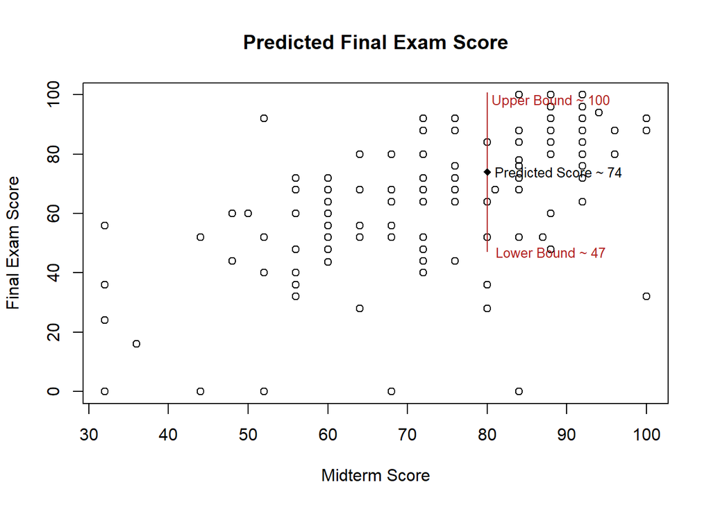

```r
plot(FinalExam ~ Midterm, data=PastGrades, ylab="Final Exam Score", xlab= "Midterm Score", main="Predicted Final Exam Score")
lines(c(80,80), mypreds[2:3],  col="firebrick")
text(89, 74, "Predicted Score ~ 74", cex=0.8)
points(80, 74, pch=18, col="black")
text(88, 98, "Upper Bound ~ 100", cex=0.8, col="firebrick")
text(88, 47, "Lower Bound ~ 47", cex=0.8, col="firebrick")
```

## Appendix

**Where the Model Came From**

I assumed that attendance would play a factor, so I colored the pairs plot by attendance and built a model from what looked significant. Interestingly, attendance has no significant relationship with Final Exam score when controlled for the Midterm score, so I dropped it from the model.

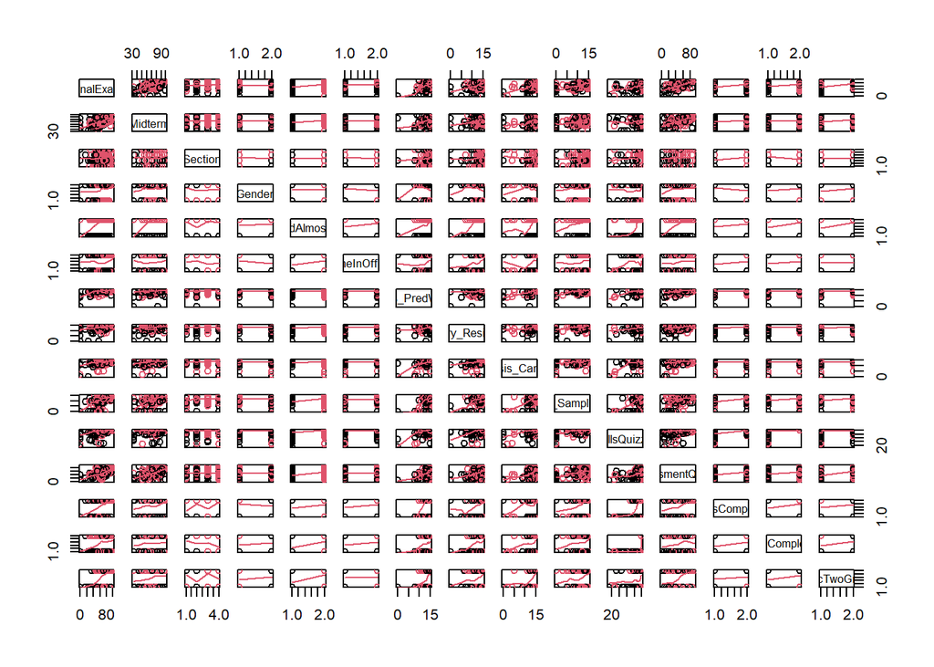

```r
pairs(PastGrades, panel=panel.smooth, col=as.factor(PastGrades$AttendedAlmostAlways))
```

```r
f1.lm<- lm(FinalExam ~ Midterm + AttendedAlmostAlways + SpentTimeInOfficeHours+Analysis_PredWeather +Theory_Residuals +Analysis_CarPrices+Theory_SamplingDists + SkillsQuizzes+ AssessmentQuizzes+ Analysis_PredWeather:AttendedAlmostAlways +AssessmentQuizzes:AttendedAlmostAlways + SpentTimeInOfficeHours:AttendedAlmostAlways, data=PastGrades)
summary(f1.lm)
```

```
##
## Call:
## lm(formula = FinalExam ~ Midterm + AttendedAlmostAlways + SpentTimeInOfficeHours +
##     Analysis_PredWeather + Theory_Residuals + Analysis_CarPrices +
##     Theory_SamplingDists + SkillsQuizzes + AssessmentQuizzes +
##     Analysis_PredWeather:AttendedAlmostAlways + AssessmentQuizzes:AttendedAlmostAlways +
##     SpentTimeInOfficeHours:AttendedAlmostAlways, data = PastGrades)
##
## Residuals:
##     Min      1Q  Median      3Q     Max
## -30.050  -7.428   1.388   8.384  26.171
##
## Coefficients:
##                                                Estimate Std. Error t value
## (Intercept)                                   -44.38082   11.90763  -3.727
## Midterm                                         0.38307    0.09802   3.908
## AttendedAlmostAlwaysY                          13.92830   17.18301   0.811
## SpentTimeInOfficeHoursY                        -0.49642    4.88700  -0.102
## Analysis_PredWeather                            1.96783    0.81828   2.405
## Theory_Residuals                               -0.02490    0.59231  -0.042
## Analysis_CarPrices                              0.67773    0.59422   1.141
## Theory_SamplingDists                            1.17647    0.40902   2.876
## SkillsQuizzes                                   0.27103    0.11278   2.403
## AssessmentQuizzes                               0.18913    0.13141   1.439
## AttendedAlmostAlwaysY:Analysis_PredWeather     -1.43500    1.37435  -1.044
## AttendedAlmostAlwaysY:AssessmentQuizzes         0.09816    0.15046   0.652
## AttendedAlmostAlwaysY:SpentTimeInOfficeHoursY  -1.43395    5.82236  -0.246
##                                               Pr(>|t|)
## (Intercept)                                   0.000313 ***
## Midterm                                       0.000164 ***
## AttendedAlmostAlwaysY                         0.419420
## SpentTimeInOfficeHoursY                       0.919282
## Analysis_PredWeather                          0.017914 *
## Theory_Residuals                              0.966543
## Analysis_CarPrices                            0.256635
## Theory_SamplingDists                          0.004865 **
## SkillsQuizzes                                 0.017988 *
## AssessmentQuizzes                             0.153041
## AttendedAlmostAlwaysY:Analysis_PredWeather    0.298802
## AttendedAlmostAlwaysY:AssessmentQuizzes       0.515569
## AttendedAlmostAlwaysY:SpentTimeInOfficeHoursY 0.805940
## ---
## Signif. codes:  0 '***' 0.001 '**' 0.01 '*' 0.05 '.' 0.1 ' ' 1
##
## Residual standard error: 13.63 on 106 degrees of freedom
##   (9 observations deleted due to missingness)
## Multiple R-squared:  0.6963, Adjusted R-squared:  0.6619
## F-statistic: 20.25 on 12 and 106 DF,  p-value: < 2.2e-16
```

```r
#R^2 0.6735
f2.lm<- lm(FinalExam ~ Midterm +Analysis_PredWeather +Theory_SamplingDists + SkillsQuizzes+ AssessmentQuizzes, data=PastGrades)
summary(f2.lm)
```

```
##
## Call:
## lm(formula = FinalExam ~ Midterm + Analysis_PredWeather + Theory_SamplingDists +
##     SkillsQuizzes + AssessmentQuizzes, data = PastGrades)
##
## Residuals:
##     Min      1Q  Median      3Q     Max
## -31.055  -8.068   1.361   8.410  30.745
##
## Coefficients:
##                       Estimate Std. Error t value Pr(>|t|)
## (Intercept)          -40.55543   10.66692  -3.802 0.000233 ***
## Midterm                0.39819    0.09513   4.186 5.65e-05 ***
## Analysis_PredWeather   1.69287    0.68877   2.458 0.015497 *
## Theory_SamplingDists   1.16589    0.36734   3.174 0.001938 **
## SkillsQuizzes          0.29503    0.10661   2.767 0.006604 **
## AssessmentQuizzes      0.26075    0.07231   3.606 0.000464 ***
## ---
## Signif. codes:  0 '***' 0.001 '**' 0.01 '*' 0.05 '.' 0.1 ' ' 1
##
## Residual standard error: 13.39 on 113 degrees of freedom
##   (9 observations deleted due to missingness)
## Multiple R-squared:  0.6873, Adjusted R-squared:  0.6735
## F-statistic: 49.67 on 5 and 113 DF,  p-value: < 2.2e-16
```

**Score Calculations**

Below are my calculations for my combined exam scores. I tested the predicted score, the lower bound, an $80\%$ on the final, a $90\%$ on the final, and the upper bound, $100\%$ on the final. If I scored a $90\%$ on the final and kept my Midterm score I would lose 3 points, while I would lose 6 points with scoring $100\%$ on the final.

```r
(.3*80) + (.7* 73.99868)
```

```
## [1] 75.79908
```

```r
(.3*80) + (.7* 47.15701)
```

```
## [1] 57.00991
```

```r
(.3*80) + (.7* 80)
```

```
## [1] 80
```

```r
(.3*80) + (.7* 90)
```

```
## [1] 87
```

```r
(.3*80) + (.7* 100)
```

```
## [1] 94
```